# Machine Learning on Weight Lifting Exercise Dataset

### Executive Summary

This report uses data from [Weight Lifting Exercise Dataset](http://groupware.les.inf.puc-rio.br/har). The study uses 2 different machine learning models - Tree and Random Forest to train based on the training dataset collected from the on-body sensors.

Comparing the 2 machine learning models, Random Forest has provided a higher accuracy with 99.31% and out of sample errors of 0.0069 for our dataset.

We then used the Random Forest learning model to predict the fashion of how the Unilateral Dumbbell Biceps Curl is conducted for 20 test cases.

### Background

The datasets contains the various readings from on-body sensors from six young health participants were asked to perform one set of 10 repetitions of the Unilateral Dumbbell Biceps Curl in five different fashions:

- Class A: exactly according to the specification
- Class B: throwing the elbows to the front
- Class C: lifting the dumbbell only halfway
- Class D: lowering the dumbbell only halfway
- Class E: throwing the hips to the front

### R Package Used for Analysis

This analysis require the use of the following packages:

- [caret](http://cran.r-project.org/web/packages/caret/index.html), which also load required package [lattice](http://cran.r-project.org/web/packages/lattice/index.html) and [ggplot2](http://cran.r-project.org/web/packages/ggplot2/index.html)
- [rpart](http://cran.r-project.org/web/packages/rpart/index.html)
- [rattle](http://cran.r-project.org/web/packages/rattle/index.html)

```r
library(caret)
library(rpart)
library(rattle)
```

### Loading Data

Load both training and testing data into memory.

```r
## user to set working directory first

## Download the data file if it does not exists in the working directory
if (!file.exists("./pml-training.csv")) {
        fileUrl <- "https://d396qusza40orc.cloudfront.net/predmachlearn/pml-training.csv"
        download.file(fileUrl, destfile = "./pml-training.csv", method = "curl")
        }

if (!file.exists("./pml-testing.csv")) {
        fileUrl <- "https://d396qusza40orc.cloudfront.net/predmachlearn/pml-testing.csv"
        download.file(fileUrl, destfile = "./pml-testing.csv", method = "curl")
        }

## read both datasets
pml.train <- read.csv("./pml-training.csv", header = TRUE, na.strings = c("NA", ""))
pml.test <- read.csv("./pml-testing.csv", header = TRUE, na.strings = c("NA", ""))
dim(pml.train)
```

```
## [1] 19622   160
```

```r
dim(pml.test)
```

```
## [1]  20 160
```

### Cleaning the Training Datasets

There are a total of 19,622 rows x 160 columns in the training datasets. Out of which, there are 100 columns with 19,216 NA, i.e. 97.93% of rows have NA values.

```r
na.train <- table(colSums(is.na(pml.train)))
na.train
```

```
##
##     0 19216
##    60   100
```

We first remove the 100 columns of majority NA values.

```r
## remove columns with all NAs
data.cols <- which(colSums(is.na(pml.train)) == 0)
cleaned.train <- subset(pml.train[ , data.cols])
colnames(cleaned.train)
```

```
##  [1] "X"                    "user_name"            "raw_timestamp_part_1"
##  [4] "raw_timestamp_part_2" "cvtd_timestamp"       "new_window"
##  [7] "num_window"           "roll_belt"            "pitch_belt"
## [10] "yaw_belt"             "total_accel_belt"     "gyros_belt_x"
## [13] "gyros_belt_y"         "gyros_belt_z"         "accel_belt_x"
## [16] "accel_belt_y"         "accel_belt_z"         "magnet_belt_x"
## [19] "magnet_belt_y"        "magnet_belt_z"        "roll_arm"
## [22] "pitch_arm"            "yaw_arm"              "total_accel_arm"
## [25] "gyros_arm_x"          "gyros_arm_y"          "gyros_arm_z"
## [28] "accel_arm_x"          "accel_arm_y"          "accel_arm_z"
## [31] "magnet_arm_x"         "magnet_arm_y"         "magnet_arm_z"
## [34] "roll_dumbbell"        "pitch_dumbbell"       "yaw_dumbbell"
## [37] "total_accel_dumbbell" "gyros_dumbbell_x"     "gyros_dumbbell_y"
## [40] "gyros_dumbbell_z"     "accel_dumbbell_x"     "accel_dumbbell_y"
## [43] "accel_dumbbell_z"     "magnet_dumbbell_x"    "magnet_dumbbell_y"
## [46] "magnet_dumbbell_z"    "roll_forearm"         "pitch_forearm"
## [49] "yaw_forearm"          "total_accel_forearm"  "gyros_forearm_x"
## [52] "gyros_forearm_y"      "gyros_forearm_z"      "accel_forearm_x"
## [55] "accel_forearm_y"      "accel_forearm_z"      "magnet_forearm_x"
## [58] "magnet_forearm_y"     "magnet_forearm_z"     "classe"
```

From the remaining 60 columns, we next remove Columns 1 - 7 which we find that these are not features required for our learning models.

```r
## remove Columns 1 - 7
cleaned.train <- subset(cleaned.train[ , -c(1:7)])
dim(cleaned.train)
```

```
## [1] 19622    53
```

Next, we plot the distribution of the 5 different fashions of performing Unilateral Dumbbell Biceps Curl for the training datasets.

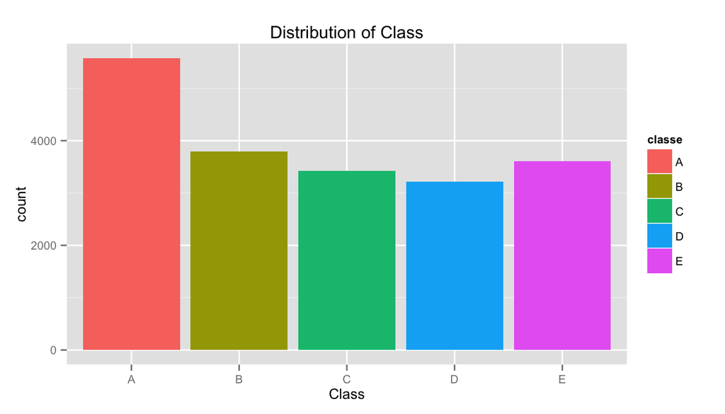

### Data Partioning for Cross Validation

After cleaning the training dataset, we split it into training and testing (for validation) datasets, using random subsampling of p = 0.75.

```r
## Split the dataset for training and testing
inTrain <- createDataPartition(y=cleaned.train$classe, p=0.75, list=FALSE)
training <- cleaned.train[inTrain, ]
testing <- cleaned.train[-inTrain, ]
dim(training)
```

```
## [1] 14718    53
```

```r
dim(testing)
```

```
## [1] 4904   53
```

### Machine Learning

Before we start to build our model, we set the seed of R’s random number generator to 32786 which will allow the learning models to be reproduced.

```r
set.seed(32786)
```

### Model 1 - Tree

We predict with learning model tree. We use rpart package which produce a more accurate learning model for our datasets.

```r
## Predicting with Trees
rpmod <- rpart(classe ~ ., data=training, method="class")
rpmod
```

```
## n= 14718
##
## node), split, n, loss, yval, (yprob)
##       * denotes terminal node
##
##     1) root 14718 10533 A (0.28 0.19 0.17 0.16 0.18)
##       2) roll_belt< 129.5 13409  9276 A (0.31 0.21 0.19 0.18 0.11)
##         4) pitch_forearm< -33.95 1169     7 A (0.99 0.006 0 0 0) *
##         5) pitch_forearm>=-33.95 12240  9269 A (0.24 0.23 0.21 0.2 0.12)
##          10) yaw_belt>=169.5 602    61 A (0.9 0.045 0 0.05 0.0066) *
##          11) yaw_belt< 169.5 11638  8824 B (0.21 0.24 0.22 0.2 0.12)
##            22) magnet_dumbbell_z< -93.5 1422   576 A (0.59 0.28 0.048 0.057 0.025)
##              44) magnet_dumbbell_y>=-564.5 1077   233 A (0.78 0.17 0.0074 0.013 0.026) *
##              45) magnet_dumbbell_y< -564.5 345   136 B (0.0058 0.61 0.17 0.19 0.02) *
##            23) magnet_dumbbell_z>=-93.5 10216  7717 C (0.16 0.24 0.24 0.23 0.14)
##              46) pitch_belt< -42.95 623    94 B (0.013 0.85 0.088 0.026 0.024) *
##              47) pitch_belt>=-42.95 9593  7149 C (0.16 0.2 0.25 0.24 0.15)
##                94) accel_dumbbell_y>=-39.5 8811  6558 D (0.18 0.21 0.21 0.26 0.15)
##                 188) magnet_dumbbell_y< 291.5 3963  2420 C (0.2 0.11 0.39 0.18 0.12)
##                   376) magnet_belt_z< -322.5 2342  1682 A (0.28 0.12 0.25 0.19 0.16)
##                     752) roll_belt>=123.5 392    65 A (0.83 0.041 0.043 0 0.082) *
##                     753) roll_belt< 123.5 1950  1385 C (0.17 0.14 0.29 0.23 0.17)
##                      1506) accel_dumbbell_y< 21.5 1582  1091 C (0.21 0.17 0.31 0.26 0.052)
##                        3012) magnet_dumbbell_y>=218 372   144 A (0.61 0.24 0.022 0.011 0.12) *
##                        3013) magnet_dumbbell_y< 218 1210   727 C (0.084 0.15 0.4 0.34 0.033)
##                          6026) pitch_belt>=1 1067   584 C (0.095 0.16 0.45 0.25 0.037)
##                           12052) pitch_forearm< 33.2 679   250 C (0.077 0.14 0.63 0.13 0.028) *
##                           12053) pitch_forearm>=33.2 388   208 D (0.13 0.22 0.14 0.46 0.054) *
##                          6027) pitch_belt< 1 143     1 D (0.007 0 0 0.99 0) *
##                      1507) accel_dumbbell_y>=21.5 368   114 E (0.0082 0.019 0.2 0.082 0.69) *
##                   377) magnet_belt_z>=-322.5 1621   660 C (0.072 0.099 0.59 0.16 0.076)
##                     754) yaw_arm< -108 108     2 A (0.98 0.019 0 0 0) *
##                     755) yaw_arm>=-108 1513   552 C (0.0066 0.1 0.64 0.17 0.081) *
##                 189) magnet_dumbbell_y>=291.5 4848  3299 D (0.16 0.28 0.062 0.32 0.18)
##                   378) yaw_belt< -2.825 3965  2636 B (0.19 0.34 0.057 0.22 0.2)
##                     756) yaw_belt>=-9.41 384     2 B (0.0052 0.99 0 0 0) *
##                     757) yaw_belt< -9.41 3581  2634 B (0.21 0.26 0.063 0.25 0.22)
##                      1514) magnet_dumbbell_z< -16.5 836   358 A (0.57 0.26 0 0.15 0.019)
##                        3028) gyros_dumbbell_y< 0.625 714   238 A (0.67 0.14 0 0.17 0.02) *
##                        3029) gyros_dumbbell_y>=0.625 122     4 B (0.016 0.97 0 0 0.016) *
##                      1515) magnet_dumbbell_z>=-16.5 2745  1970 E (0.095 0.26 0.082 0.28 0.28)
##                        3030) accel_forearm_x>=-105.5 2011  1331 E (0.11 0.32 0.1 0.13 0.34)
##                          6060) roll_belt>=-0.675 1630   992 B (0.14 0.39 0.12 0.088 0.26)
##                           12120) total_accel_dumbbell< 6.5 259   112 A (0.57 0.1 0 0.26 0.073) *
##                           12121) total_accel_dumbbell>=6.5 1371   759 B (0.059 0.45 0.15 0.056 0.29)
##                             24242) roll_dumbbell< 41.87526 258    20 B (0.027 0.92 0.0078 0.0039 0.039) *
##                             24243) roll_dumbbell>=41.87526 1113   725 E (0.066 0.34 0.18 0.068 0.35)
##                               48486) magnet_belt_z>=-345 711   359 B (0.073 0.5 0.28 0.053 0.096) *
##                               48487) magnet_belt_z< -345 402    82 E (0.055 0.055 0 0.095 0.8) *
##                          6061) roll_belt< -0.675 381   118 E (0.0052 0.0079 0 0.3 0.69)
##                           12122) magnet_dumbbell_z>=246 113     0 D (0 0 0 1 0) *
##                           12123) magnet_dumbbell_z< 246 268     5 E (0.0075 0.011 0 0 0.98) *
##                        3031) accel_forearm_x< -105.5 734   234 D (0.041 0.12 0.031 0.68 0.13) *
##                   379) yaw_belt>=-2.825 883   213 D (0.052 0.039 0.085 0.76 0.066) *
##                95) accel_dumbbell_y< -39.5 782   182 C (0.018 0.1 0.77 0.041 0.069) *
##       3) roll_belt>=129.5 1309    52 E (0.04 0 0 0 0.96) *
```

Using rattle package to create a nice plot of the decision tree for our learning model.

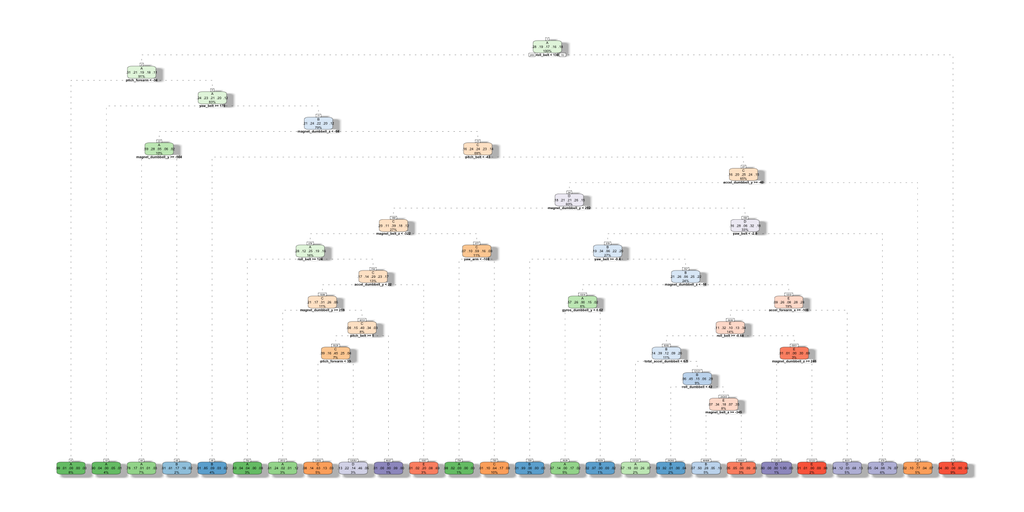

```r
## Use rattle package to do a plot of the tree
fancyRpartPlot(rpmod, sub="", main="")
```

We then use the learning model to predict the class for our testing dataset and do a comparison of the prediction against the actual answer.

```r
p.rpmod <- predict(rpmod, newdata=testing, type="class")
confusionMatrix(testing$classe, p.rpmod)
```

```
## Confusion Matrix and Statistics
##
##           Reference
## Prediction    A    B    C    D    E
##          A 1268   26   27   46   28
##          B  152  586  130   72    9
##          C   14  110  656   56   19
##          D   89   40  115  541   19
##          E   53   37   75   48  688
##
## Overall Statistics
##
##                Accuracy : 0.7624
##                  95% CI : (0.7503, 0.7743)
##     No Information Rate : 0.3214
##     P-Value [Acc > NIR] : < 2.2e-16
##
##                   Kappa : 0.6983
##  Mcnemar's Test P-Value : < 2.2e-16
##
## Statistics by Class:
##
##                      Class: A Class: B Class: C Class: D Class: E
## Sensitivity            0.8046   0.7334   0.6540   0.7090   0.9017
## Specificity            0.9618   0.9116   0.9490   0.9365   0.9486
## Pos Pred Value         0.9090   0.6175   0.7673   0.6729   0.7636
## Neg Pred Value         0.9122   0.9461   0.9143   0.9459   0.9813
## Prevalence             0.3214   0.1629   0.2045   0.1556   0.1556
## Detection Rate         0.2586   0.1195   0.1338   0.1103   0.1403
## Detection Prevalence   0.2845   0.1935   0.1743   0.1639   0.1837
## Balanced Accuracy      0.8832   0.8225   0.8015   0.8228   0.9251
```

From the result, we can see that this machine learning model has a **accuracy** of **76.24%** and **out of sample errors** of 1 - accuracy, i.e. **0.24**.

### Model 2 - Random Forest

We predict with learning model Random Forest. We use caret package for the analysis.

```r
rfmod <- train(classe ~ ., method="rf", data=training)
```

```r
rfmod$finalModel
```

```
##
## Call:
##  randomForest(x = x, y = y, mtry = param$mtry)
##                Type of random forest: classification
##                      Number of trees: 500
## No. of variables tried at each split: 2
##
##         OOB estimate of  error rate: 0.61%
## Confusion matrix:
##      A    B    C    D    E  class.error
## A 4182    2    0    0    1 0.0007168459
## B   15 2827    6    0    0 0.0073735955
## C    0   16 2548    3    0 0.0074016362
## D    0    0   39 2372    1 0.0165837479
## E    0    0    1    6 2699 0.0025868441
```

We then use the learning model to predict the class for our testing dataset and do a comparison of the prediction against the actual answer.

```r
p.rfmod <- predict(rfmod, newdata=testing)
confusionMatrix(testing$classe, p.rfmod)
```

```
## Confusion Matrix and Statistics
##
##           Reference
## Prediction    A    B    C    D    E
##          A 1393    2    0    0    0
##          B    5  940    4    0    0
##          C    0    6  848    1    0
##          D    0    0   15  789    0
##          E    0    0    0    1  900
##
## Overall Statistics
##
##                Accuracy : 0.9931
##                  95% CI : (0.9903, 0.9952)
##     No Information Rate : 0.2851
##     P-Value [Acc > NIR] : < 2.2e-16
##
##                   Kappa : 0.9912
##  Mcnemar's Test P-Value : NA
##
## Statistics by Class:
##
##                      Class: A Class: B Class: C Class: D Class: E
## Sensitivity            0.9964   0.9916   0.9781   0.9975   1.0000
## Specificity            0.9994   0.9977   0.9983   0.9964   0.9998
## Pos Pred Value         0.9986   0.9905   0.9918   0.9813   0.9989
## Neg Pred Value         0.9986   0.9980   0.9953   0.9995   1.0000
## Prevalence             0.2851   0.1933   0.1768   0.1613   0.1835
## Detection Rate         0.2841   0.1917   0.1729   0.1609   0.1835
## Detection Prevalence   0.2845   0.1935   0.1743   0.1639   0.1837
## Balanced Accuracy      0.9979   0.9946   0.9882   0.9969   0.9999
```

From the result, we can see that this machine learning model has a **accuracy** of **99.31%** and **out of sample errors** of 1 - accuracy, i.e. **0.0069**.

### Prediction

From the 2 machine learning models, Random Forest is the most accurate. We then use the Random Forest learning model to predict 20 test cases in the pml-test.csv.

```r
answers <- predict(rfmod, newdata=pml.test)
answers
```

```
##  [1] B A B A A E D B A A B C B A E E A B B B
## Levels: A B C D E
```

#### Reference:

[Velloso, E.](http://groupware.les.inf.puc-rio.br/collaborator.jsf?p1=evelloso); Bulling, A.; Gellersen, H.; [Ugulino, W.](http://groupware.les.inf.puc-rio.br/collaborator.jsf?p1=ugulino); [Fuks, H.](http://groupware.les.inf.puc-rio.br/collaborator.jsf?p1=hugo) [Qualitative Activity Recognition of Weight Lifting Exercises](http://groupware.les.inf.puc-rio.br/work.jsf?p1=11201). Proceedings of 4th International Conference in Cooperation with SIGCHI (Augmented Human ’13) . Stuttgart, Germany: ACM SIGCHI, 2013.